# Trabajo con GGplot2 - NeyraOcaña

### *Descripcion del Dataset*

| Campo | Descripcion |
| --- | --- |
| CaseNumber | Numero de caso |
| Mes | Mes |
| Dia | Dia |
| Anio | Anio |
| Sex | Genero |
| Race | Raza o etnia |
| Age | Edad |
| Residence.City | Ciudad de residencia |
| Residence.State | Estado de residencia |
| Residence.Country | Pais de residencia |
| Death.City | Ciudad donde fallecio |
| Death.State | Estado donde fallecio |
| Death.Country | Pais donde fallecio |
| Location | Lugar donde fallecio |
| Descriptionofinjury | Descripcion del danio |
| InjuryPlace | Lugar del danio |
| ImmediateCauseA | Causa de muerte |

### Importacion de Librerias

```r
library("lubridate")
library("tidyr")
library("stringr")
library("ggplot2")
library("dplyr")
```

### Lectura de Datos

```r
datosOriginal<-read.csv("Datasets/Accidental_Drug_Related_Deaths__2012-2017.csv")
```

### Preparacion de Datos

- Eliminar Fechas en Blanco

```r
DateBlank<-datosOriginal %>% filter(Date == "")
datosSinBlancos<-anti_join(datosOriginal,DateBlank)
```

- Generar Datos Limpios

```r
datos<-datosSinBlancos %>% separate(data = datosSinBlancos, col = Date, into = c("mes","dia","anio"),
                                    sep = "[/]",remove = TRUE, convert = FALSE,
                                    extra = "warn", fill = "warn")
```

- Eliminar Datasets Inutiles

```r
rm(DateBlank,datosSinBlancos)
```

### Consultas de Exploracion 1 (Grafico de Barras)

- Cantidad de casos ocurridos por anio

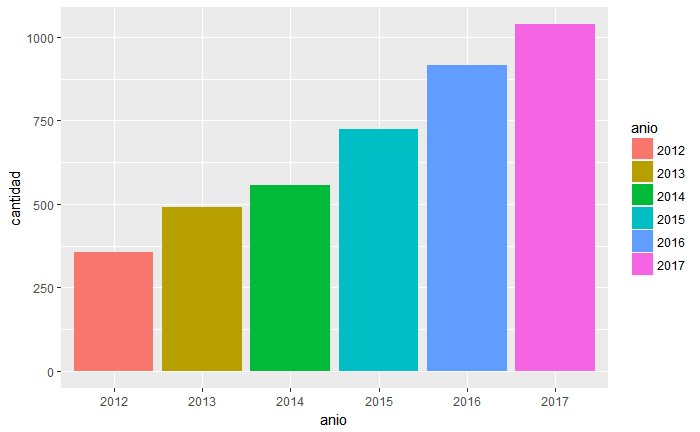

- Cantidad de casos ocurridos por mes

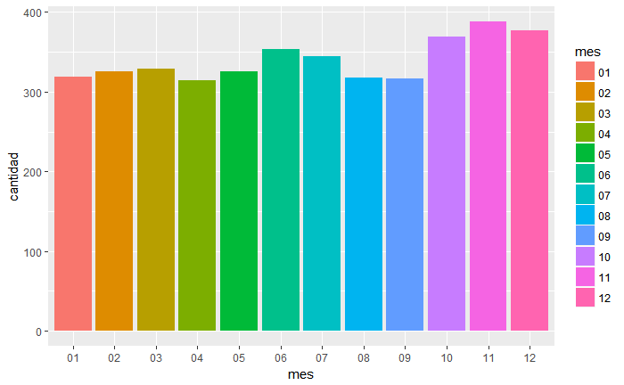

- Sexo que mas muertes accidentales ha tenido

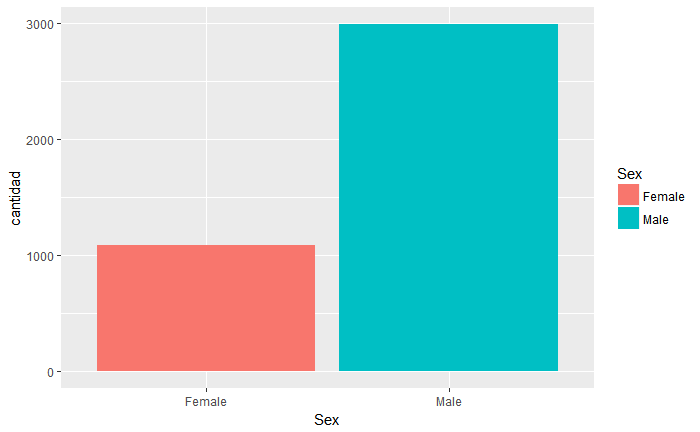

- Edad en la que mas ocurren los accidentes

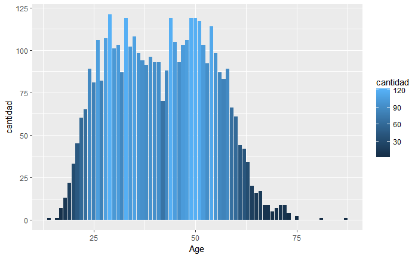

- Raza/etnia con mas accidentes

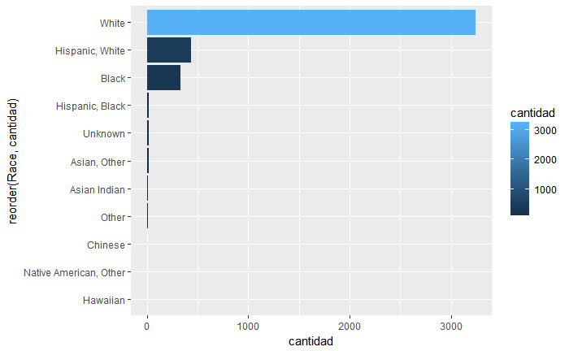

### Consultas de Exploracion 2 (Grafico de Torta)

- Top 10 de ciudades con mas accidentes

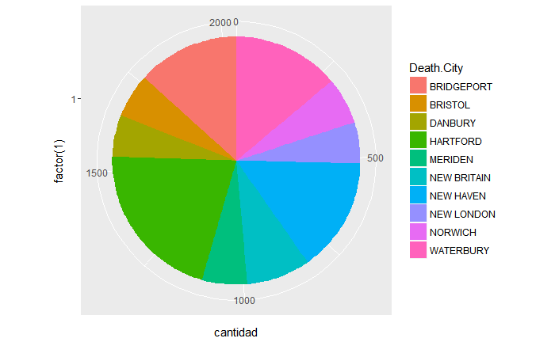

- ¿Cual es el top 8 de lugares donde las personas cometen el atentado?

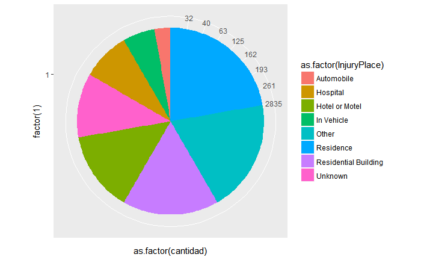

- Top 5 de causas de accidente

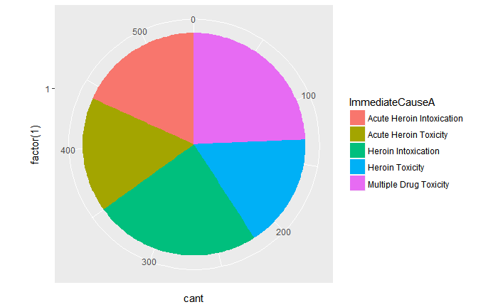

- ¿Cuales son las 2 descripciones de accidentes mas comunes?

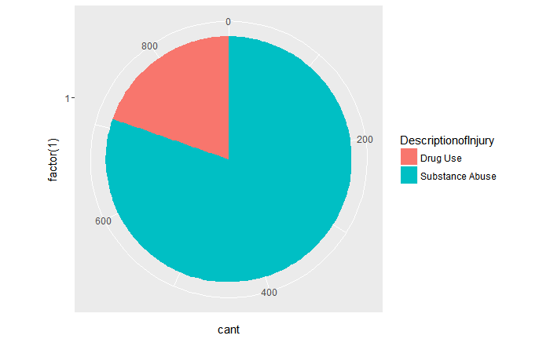

- En que mes las mujeres tienen mas accidentes mortales

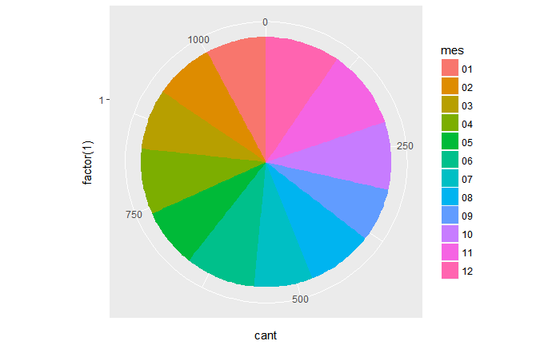

### Consultas de Exploracion 3 (Grafico de Puntos)

- Hombres blancos accidentados agrupados por dia del mes

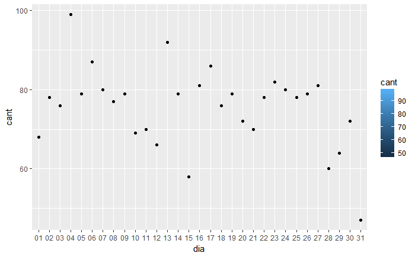

- ¿Cual es la causa de muerte por accidente mas comun?

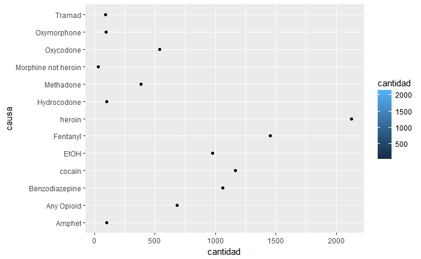

- ¿Cuales son las dos sustancias que mas causan muertes por accidente a los hombres?

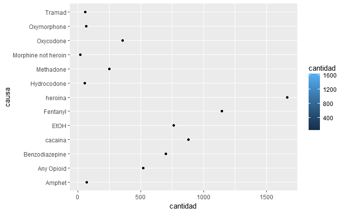

- Cantidad de hombres y mujeres que consumen heroina

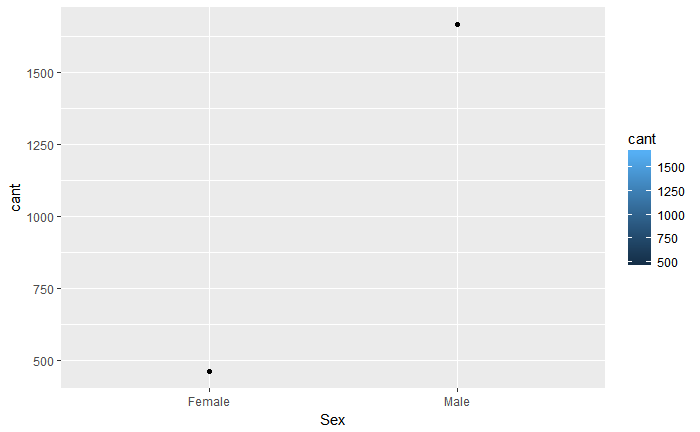

- Las 4 razas/etnicas que mas consumen cacaine

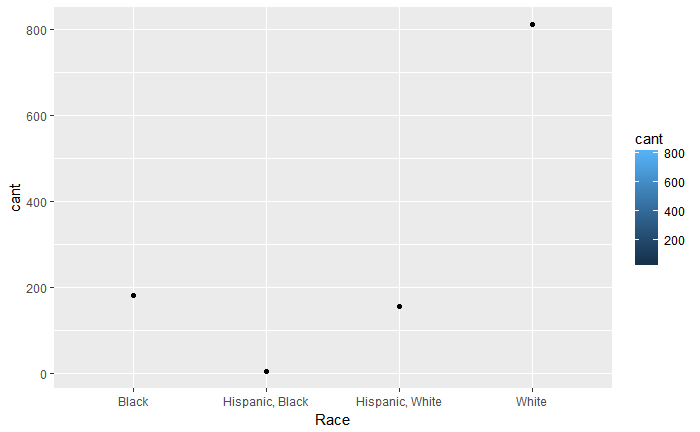

### Consultas de Exploracion 4 (Grafico de Linea)

- 10 ciudades donde provienen las personas que mas se consumen Fentanyl

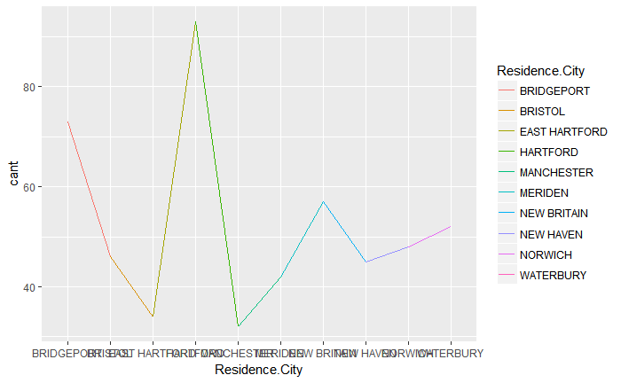

- 10 ciudades donde mas han muerto por consumo de Benzodiazepine

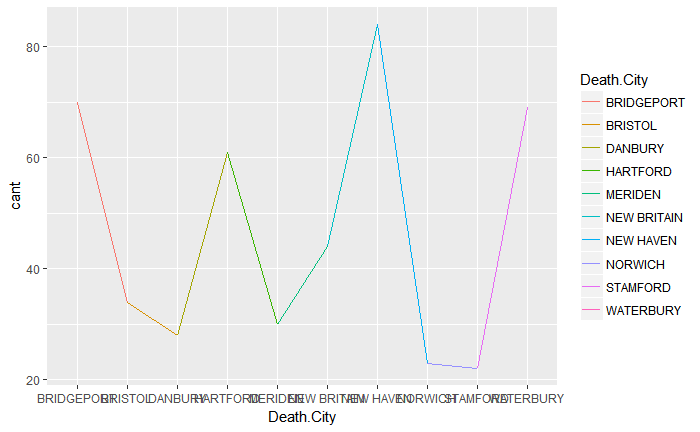

- Lugar donde mas personas murieron accidentalmente por consumo de drogas

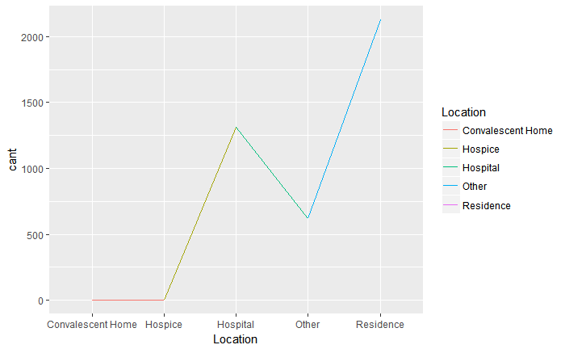

- ¿Cuales son las 5 otras sustancias mas comunes que causan estas muertes?

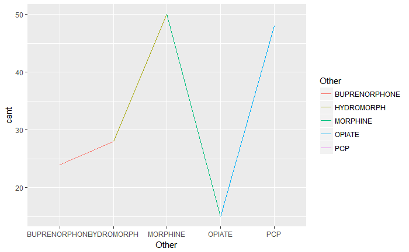

- Las 5 causas de muerte relacionadas al consumo de EtOH

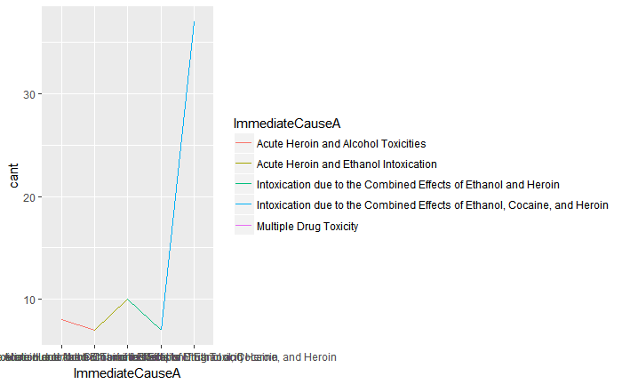

### Consultas de Exploracion 5 (Grafico de Boxplot)

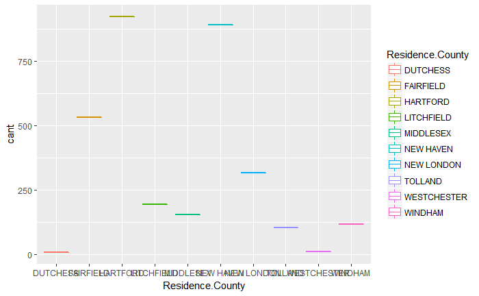

- ¿Cual es cantidad de muertos por accidente que consumieron cocaina por anio en un hospital

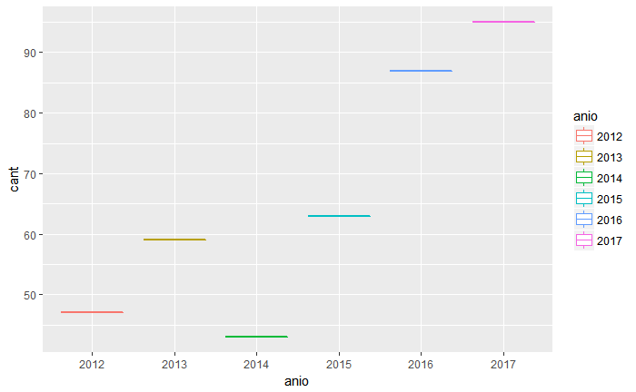

- Lista de meses donde mas se consume heroin

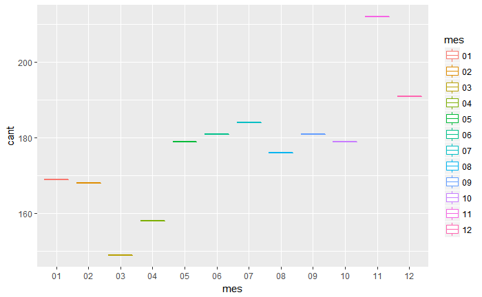

- ¿En que lugares fallecen negros?

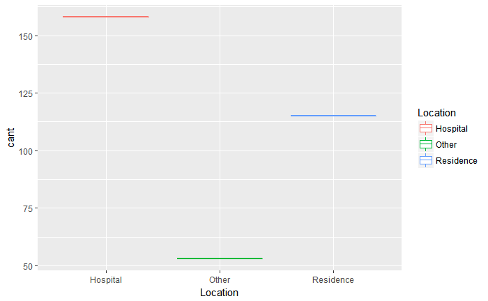

- ¿Que es lo que mas consumen los Hispanic, cocaina o heroina?

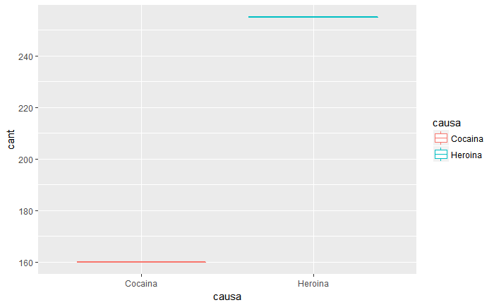

### Consultas de Exploracion 6 (Grafico de Histograma)

- ¿Que dias los hospitales tienen mas pacientes por accidentes por consumo de drogas?

```
Ignoring unknown parameters: binwidth, bins, pad
```

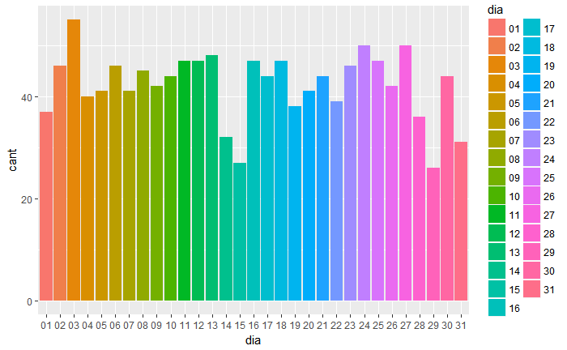

```r
ggplot(query26,aes(x=dia,y=cant,fill=dia))+ geom_histogram(stat = "identity")
```

- Personas que fallecieron en su residencia segun meses del anio 2017

```
Ignoring unknown parameters: binwidth, bins, pad
```

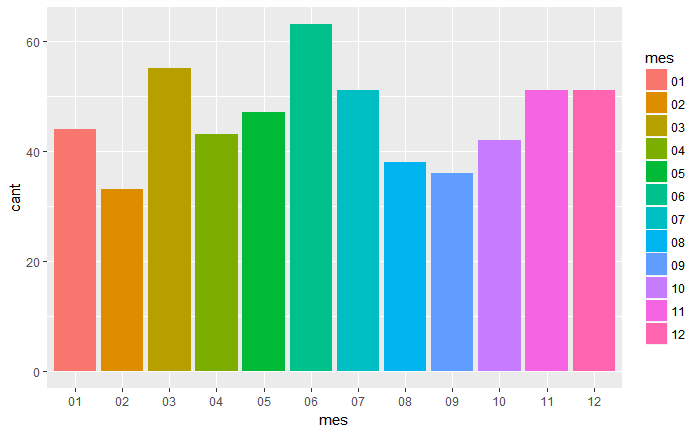

```r
ggplot(query27,aes(x=mes,y=cant,fill=mes))+ geom_histogram(stat = "identity")
```

- Lugares donde mas se consume Oxycodone

```
Ignoring unknown parameters: binwidth, bins, pad
```

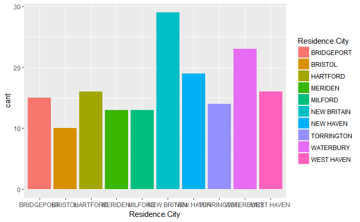

```r
ggplot(query28,aes(x=Residence.City,y=cant,fill=Residence.City))+ geom_histogram(stat = "identity")
```

- Top 10 causas de accidente en el anio 2016

```
Ignoring unknown parameters: binwidth, bins, pad
```

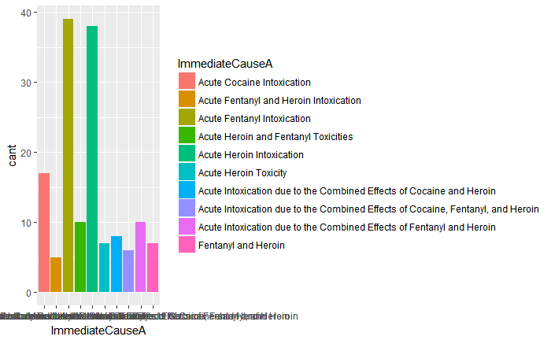

```r
ggplot(query29,aes(x=ImmediateCauseA,y=cant,fill=ImmediateCauseA))+ geom_histogram(stat = "identity")
```